# African Institute for Mathematical Sciences (AIMS)- Rwanda . Assignment 2 Statistical Machine Leaning

Joachim SINYABE DANBE

2026-05-07

## Exercice 1: Practical SML on DNA Microarrays

## 1.

The dataset exhibits the classic “**large p, small n**” problem ubiquitous in genomic studies. With **500 predictors** but only **79 samples**, we have a **n/p ratio of 0.16**, indicating extreme dimensionality. This creates a **curse of dimensionality**

## 2.

we are in high-dimensional $\kappa = 0.16$ with potential multidisciplinary. This means $n \ll p$ and overfitting is an serious risk for flexible models like trees and kNN. Thus regularisation or feature selection selection is crucial.

## 3. Response Distribution

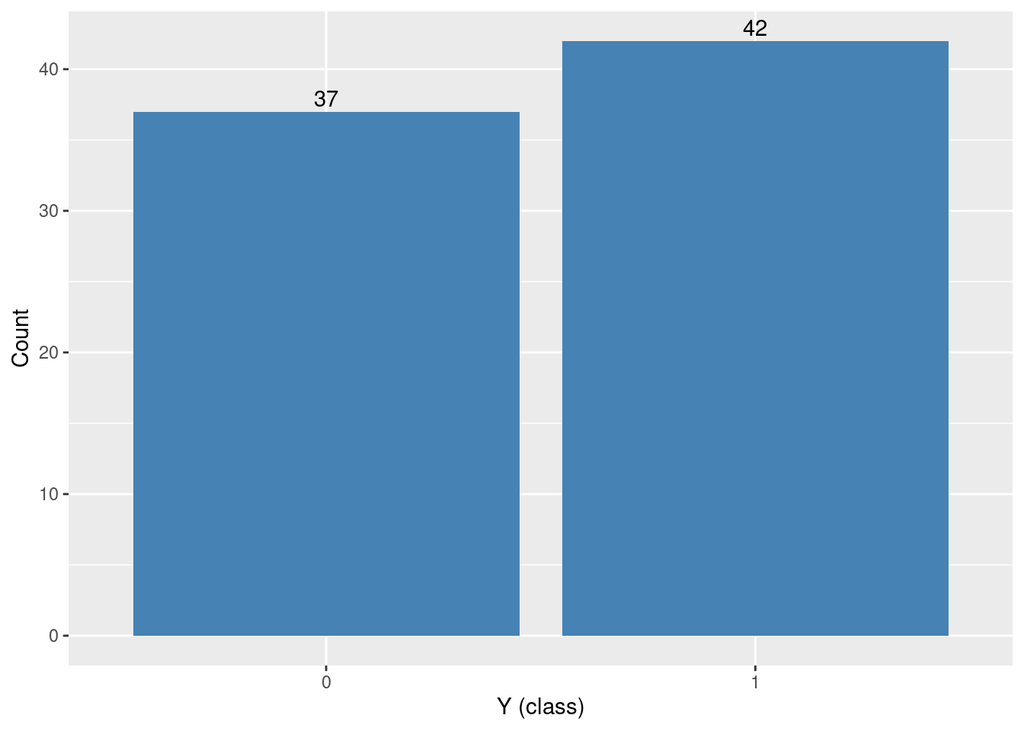

: Distribution of response

We have 37 observations in class 0(non-cacer) and 42 in class 1 (cancer), so the classes are fairly balanced $46.83\% \text{ and } 53.16 \%$. This is good for us because test error and ROC curves will be more meaningful;

## 4. Kruskal–Wallis ranking and top 9 variables

THese are the top 9 predictors according to Kruskal-Wallis test, the first is $X217844\_at$

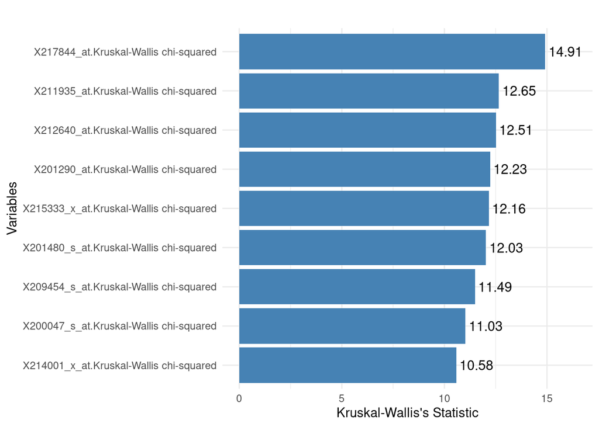

: Top 9 predictors according to Kruskal-Wallis test

## 5. Kruskal-Wallis Plot

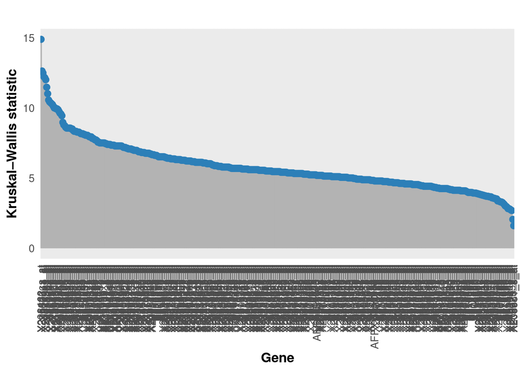

: Univariate gene ranking (Kruskal–Wallis)

We observe from this type= ’h’ plot a small subset of genes with signicantly higher Krustkal-Wallis values, indicating strong univariate associations with cancer status. Most genes show low values, suggesting limited individual predictive power.

## 6. Boxplots of top 9 variables

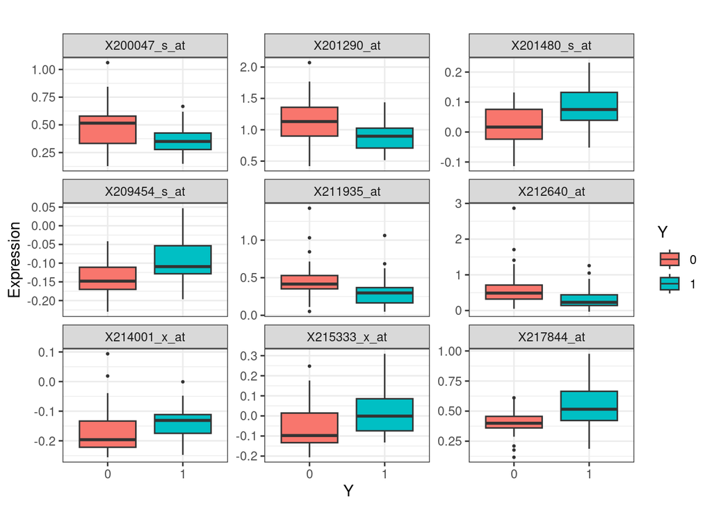

: Top 9 genes vs response

## 7. Classification Tree with cp=0.01

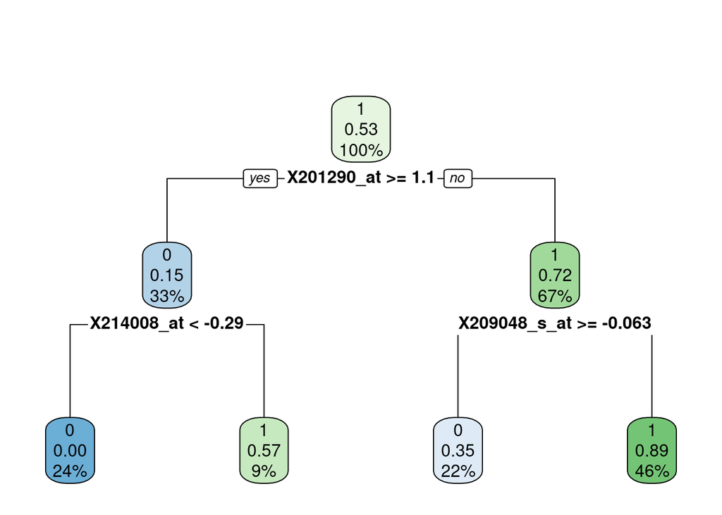

: Classification Tree (cp=0.01)

## 8. Comparative Boxplots: 9 Weakest Genes

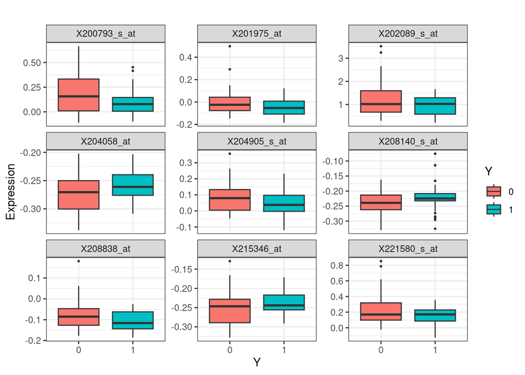

: 9 weakest genes vs response

We remark :

-Near-complete overlap of boxplots between classes; -Similr medians and spreads -No consistent expression patterns -These genes carry essentially no discrimitative signal

So feature selection is crucial to remove such noisy variables

## 9. Correlation Matrix

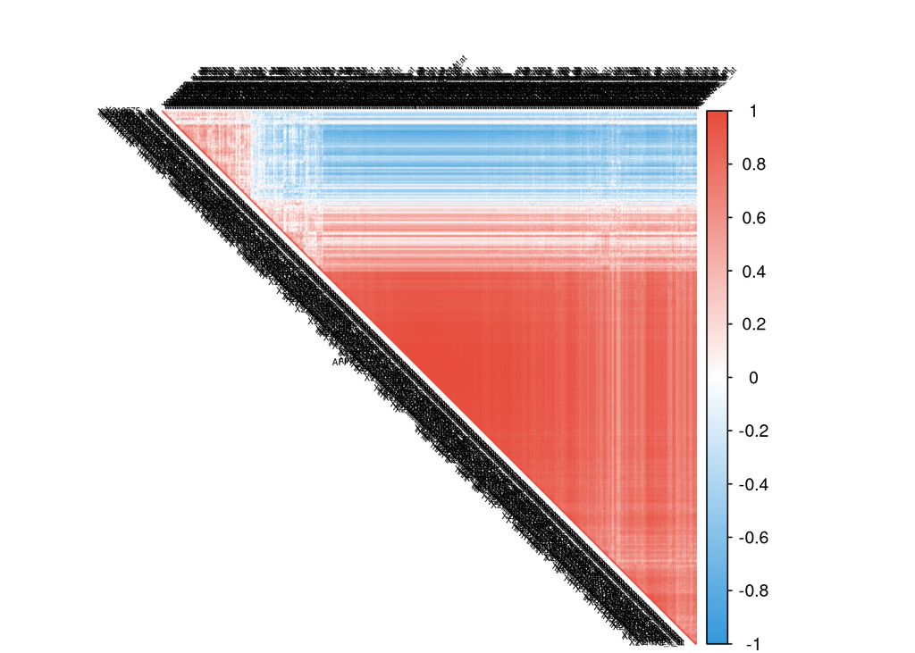

: Correlation matrix of gene expression

The clustered correlation shows large red blocks of very strong correlations, indicating that many genes are tightly co-expressed and highly redundant. The block structure reveals distinct gene modules with high within-block correlations, consistent maybe with co-regulated biological pathways.

correlation are mostly positive, suggesting that genes tend to co-express rather than regulate each other antagonisticaly . The stong multicollinearity cofirm the effective dimensionality much lower than the num ber of genes, so dimension reduction (PCA) and regularized models are preferable to naive methods taht assume independent predictors.

# 10. Eigendecomposition

$\lambda_{\max}/\lambda_{\min}$ is very large $5.48\times 10^{15}$ shows that the correlation matrice is strongly ill-conditioned: variance is concetrated along a few principal directions, while some directions carry almost no variance. This mean that the predictor space is highly anisotropic and that many linear combination of genes are nearly redundant.

# 11. ROC Curves (Full Data as Train/Test)

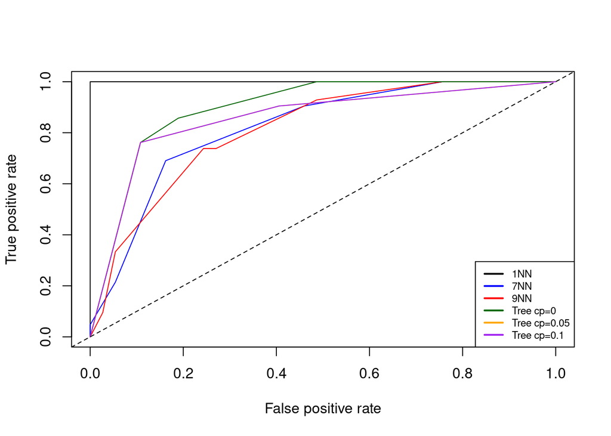

: ROC curves (train = test)

## 12

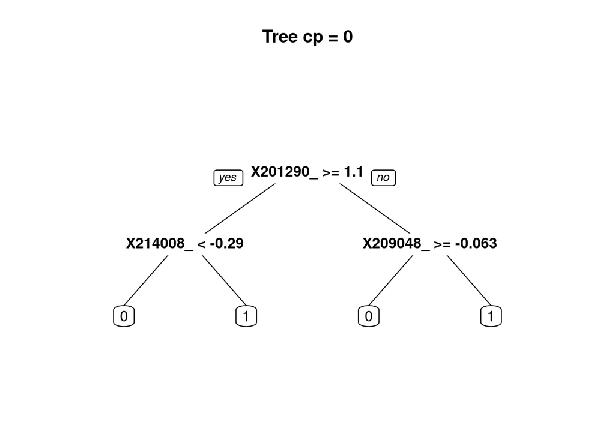

: Tree with different cp

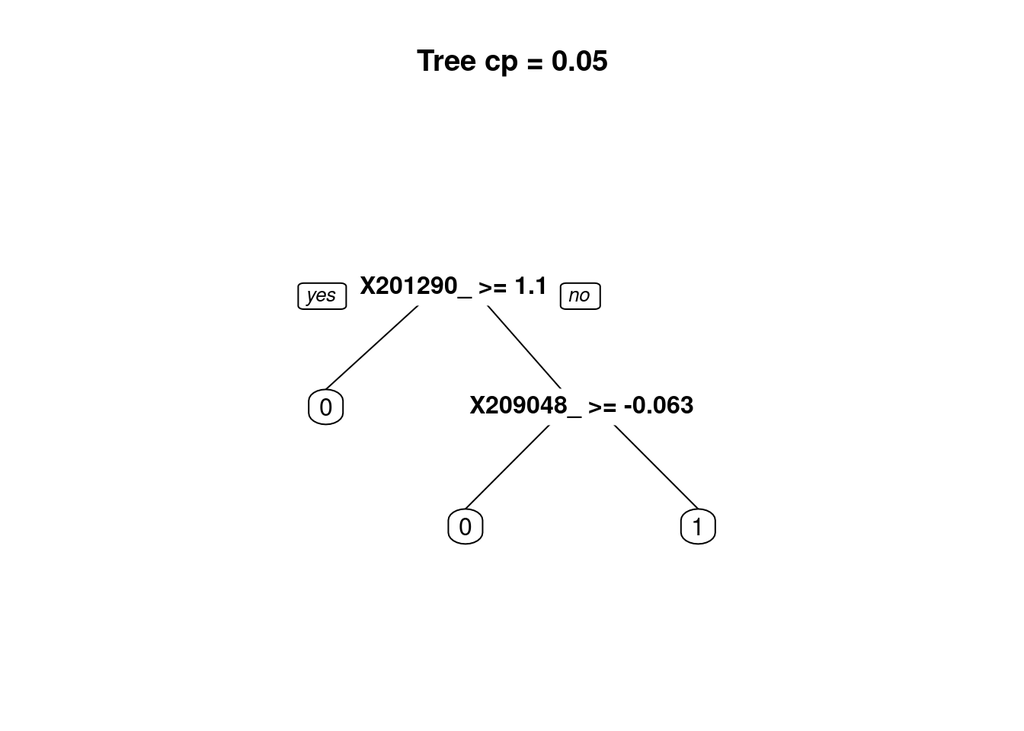

: Tree with different cp

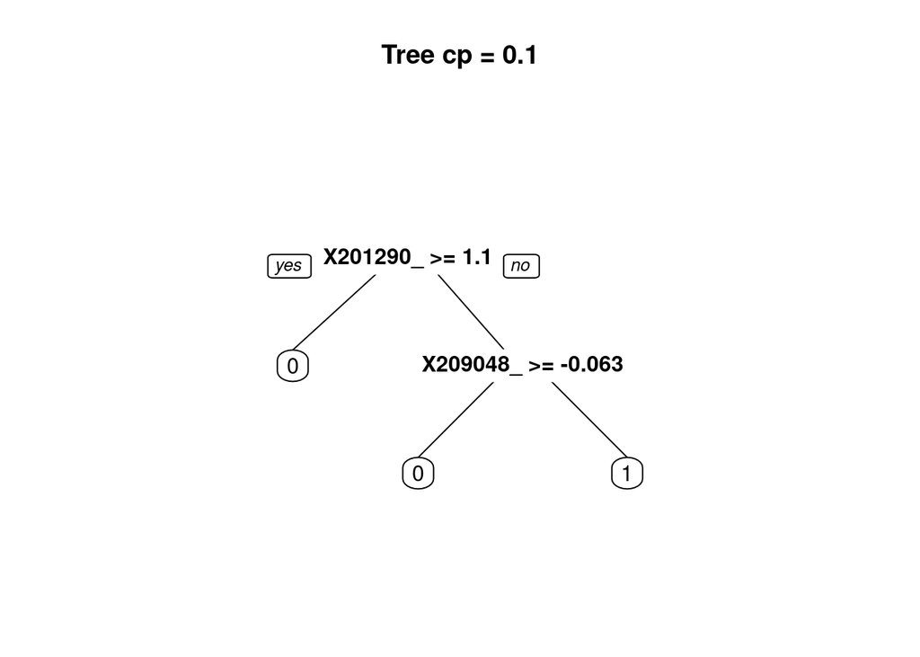

: Tree with different cp

## 13. ROC Curve Interpretation

This was expected in high-dimensional settings $(p \gg n)$ because :

These ROC curves curves optimistic bias and say little about generalization ability. Proper validation (train test splits or cross-validation) is essential.

# 14. Repeated Holdout Analysis (S=100)

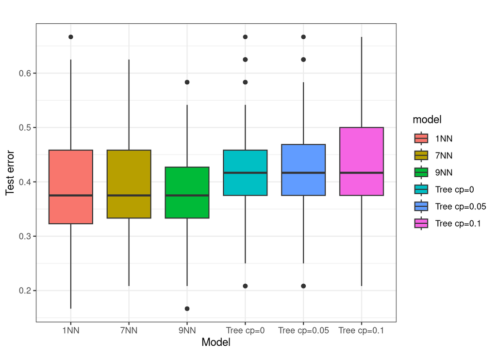

: Test error over 100 random splits

- 1NN, 7NN, 9NN show a similar error distributions
- Trees with $cp = 0$ has a higher median error than kNN
- Trees with $cp=0.05, 0.1$ have highest errors In term of complexity relationship, we can say model complexity doesn’t guarantee better test performance in high-dimensional settings

# 15. General Observations ans lessons

Form this analysis we note that

**Theoretical implications.**  
The exploration illustrates bias–variance trade‑off in high dimensions: highly flexible models can achieve almost zero training errors but often generalize poorly. The effective dimensionality of the gene‑expression space is much lower than the nominal $p = 500$, which supports using methods that explicitly exploit this structure, such as sparse models, principal component analysis, and regularized learners.

## Exercise 2 ; Nearest Neighbors as a Kernel Method

Consider$Y \in \{-1,+1\}$ a binary response and use the $k$-Nearest Neighbours learning machine.
Recognizing that the weight $w_i(x)$ is a decreasing function of the distance (dissimilarity) between $x$ and $x_i$, we reinterpret $w_i(x)$ as a similarity measure between $x$ and $x_i$.
Using a bivariate kernel function $\mathcal{K} : \mathcal{X} \times \mathcal{X} \to \mathbb{R}_+$, we adopt the negative exponential weighting scheme:
$$\mathcal{K}(x,x_i) = w_i(x)
= \frac{\exp\bigl(-\gamma d(x,x_i)\bigr)}
{\sum_{l} \exp\bigl(-\gamma d(x,x_l)\bigr)},$$
where $\gamma > 0$ is a bandwidth parameter.
Let $\alpha_i = \mathbf{1}\{x_i \in \mathcal{V}_k(x)\}$ be the neighborhood indicator, where $\mathcal{V}_k(x) \subseteq \mathcal{D} \subset \mathcal{X}$ denotes the set of $k$ nearest neighbours of $x$.

## 1.

$\hat f_{kNN}(x)$ gives the predicted label because for a query point $\mathbf{x}$, the kernel weights $K(\mathbf{x},\mathbf{x}_i)$ are non‑negative and sum to 1, so $\sum_i y_i \alpha_i K(\mathbf{x},\mathbf{x}_i)$ is a weighted average of neighbor labels $-1$ and $+1$. If the average is positive, there is more total weight on neighbors with label $+1$; if it is negative, there is more weight on neighbors with label $-1$, so taking the sign returns the majority class and therefore a predicted label in $\{-1,+1\}$.

## 2.

$\hat\pi(\mathbf{x}) = \sum_{i=1}^n \mathbf{1}(y_i = 1)\alpha_i K(\mathbf{x},\mathbf{x}_i)$ is the kernel‑weighted proportion of neighbors with label $+1$. Under standard k‑NN assumptions, its estimates the conditional class probability $\pi(\mathbf{x}) = P(Y=1\mid X=\mathbf{x})$

## 3. Relationship between $\hat f_{kNN}(x)$ and $\hat g_{kNN}(x)$

Because labels are $\{-1,+1\}$, class $+1$ corresponds to $\pi(\mathbf{x})>1/2$ and class $-1$ to $\pi(\mathbf{x})\le 1/2$. The function $\hat g_{kNN}(x)=2\,\mathbf{1}(\hat\pi(\mathbf{x})>1/2)-1$ returns $+1$ or $-1$ using this probability threshold, and this is equivalent to taking the sign of the centered probability, so $\hat g_{kNN}(x)$ and $\hat f_{kNN}(x)$ implement the same classification rule.

## 4.

$\mathcal{Y} = \{0,1\}$ since the function space $\mathcal{H} = \{ f : \mathcal{X} \rightarrow \mathcal{Y} \, | \, f(\mathbf{x}) = \mathbf{1}(\hat\pi(\mathbf{x})>1/2)\}$ uses indicator outputs. Each function in $\mathcal{H}$ maps inputs $\mathbf{x}$ to 0 for the negative class and 1 for the positive class.

## 5. Another hypothesis space in similar form

Another common hypothesis space defined via an estimated probability is the set of logistic‑regression classifiers,
$$\mathcal{H}_{\text{logit}}
= \left\{ f_\beta : \mathcal{X}\to\{0,1\} \,\middle|\,
f_\beta(\mathbf{x}) = \mathbf{1}\big(\sigma(\beta^\top
\mathbf{x})>1/2\big) \right\},$$
where $\sigma(t)$ is the logistic function and $\sigma(\beta^\top \mathbf{x})$ estimates $P(Y=1\mid X=\mathbf{x})$ for some parameter vector $\beta$. Like the k‑NN rule, this space consists of decision functions that threshold an estimated conditional class probability at $1/2$.

# Bonus Exercise: Understanding of Training vs Test

Given a dataset $\mathcal{D} = \{Z_1, Z_2, \ldots, Z_n\}$ Let $m = |\mathcal{D}_{\text{TR}}|$ and $s = |\mathcal{D}_{\text{TE}}|$.\ And
$$\hat{R}_{\text{TR}}(f) = \frac{1}{m}
\sum_{i=1}^{n} \ell(Y_i, f(X_i)) \mathbf{1}(Z_i \in
\mathcal{D}_{\text{TR}})$$
$$\hat{R}_{\text{TE}}(f) = \frac{1}{s}
\sum_{j=1}^{n} \ell(Y_j, f(X_j)) \mathbf{1}(Z_j \in
\mathcal{D}_{\text{TE}})$$

$$\hat{f} = \arg\min_{f \in
\mathcal{H}}\{\hat{R}_{\text{TR}}(f)\}$$

$$\tilde{f} = \arg\min_{f \in
\mathcal{H}}\{\hat{R}_{\text{TE}}(f)\}$$

Let’s show that $\mathbb{E}(\hat{R}_{\text{TR}}(\hat{f})) \leq \mathbb{E}(\hat{R}_{\text{TE}}(\hat{f}))$, where $\hat{f}$ is the empirical risk minimizer on the training set.

Now that :

$$\hat{f} = \arg\min_{f \in
\mathcal{H}}\{\hat{R}_{\text{TR}}(f)\} \quad \text{and} \quad \tilde{f}
= \arg\min_{f \in \mathcal{H}}\{\hat{R}_{\text{TE}}(f)\}$$

$$A = \hat{R}_{\text{TR}}(\hat{f}) =
\frac{1}{m} \sum_{i=1}^{n} \ell(Y_i, \hat{f}(X_i)) \mathbf{1}(Z_i \in
\mathcal{D}_{\text{TR}}) \,\quad B = \hat{R}_{\text{TE}}(\hat{f}) =
\frac{1}{s} \sum_{j=1}^{n} \ell(Y_j, \hat{f}(X_j)) \mathbf{1}(Z_j \in
\mathcal{D}_{\text{TE}})$$

$$C = \hat{R}_{\text{TR}}(\tilde{f}) =
\frac{1}{m} \sum_{i=1}^{n} \ell(Y_i, \tilde{f}(X_i)) \mathbf{1}(Z_i \in
\mathcal{D}_{\text{TR}}) \, \quad D = \hat{R}_{\text{TE}}(\tilde{f}) =
\frac{1}{s} \sum_{j=1}^{n} \ell(Y_j, \tilde{f}(X_j)) \mathbf{1}(Z_j \in
\mathcal{D}_{\text{TE}})$$

Here $A$ is the training error of $\hat{f}$, $B$ its test error, $C$ the training error of $\tilde{f}$, and $D$ its the test error.

We know as the split into train and test is completely symmetric: each $Z_i$ is i.i.d., and any subset of the right size can be th training or the test set. Since the training on one part and testing on the other (giving $B$) has the same distribution as training on the other part and testing on the first (giving $C$). Therefore
$$\mathbb{E}(B) = \mathbb{E}(C).$$

For the same symmetry reason as the previous, the best possible training error on the training set and on the test set have the same distributions. In other words, the distributions of $\min_{f\in\mathcal{H}} \hat{R}_{\text{TR}}(f) = A$ and $\min_{f\in\mathcal{H}} \hat{R}_{\text{TE}}(f) = D$ are the same, so
$$\mathbb{E}(A) = \mathbb{E}(D).$$

By definition,
$$\tilde{f} = \arg\min_{f \in \mathcal{H}} \hat{R}_{\text{TE}}(f),$$
so for every $f \in \mathcal{H}$,
$$\hat{R}_{\text{TE}}(\tilde{f}) \le \hat{R}_{\text{TE}}(f).$$
In particular, for $f = \hat{f}$,
$$D = \hat{R}_{\text{TE}}(\tilde{f}) \le \hat{R}_{\text{TE}}(\hat{f}) = B,$$
and taking expectations gives
$$\mathbb{E}(D) \le \mathbb{E}(B).$$

Putting everything together,
$$\mathbb{E}(A) = \mathbb{E}(D) \le \mathbb{E}(B) = \mathbb{E}(C).$$
Since $A = \hat{R}_{\text{TR}}(\hat{f})$ and $B = \hat{R}_{\text{TE}}(\hat{f})$, we obtain
$$\mathbb{E}\big[\hat{R}_{\text{TR}}(\hat{f})\big]
\le
\mathbb{E}\big[\hat{R}_{\text{TE}}(\hat{f})\big],$$
which is the desired inequality.